# ML-моделирование

[figure not shown]

## Общая информация

В проекте решается задача предиктивной оценки качества готовой металлургической продукции на основе рецептуры шихты и параметров производственного процесса. На основе исторических данных более чем за 8 лет строится модель множественной регрессии, прогнозирующая шесть ключевых показателей качества. Это позволяет технологу заранее оценивать результат подбора компонентов до формирования производственной карты и снижать риск выпуска некондиционных партий.

Для моделирования используются данные по 35 признакам, временным меткам и производственным агрегатам. Основная цель — создать интерпретируемую ML-модель, которая не только дает прогноз, но и показывает влияние ключевых факторов, помогает выбирать более устойчивые рецептуры и поддерживает принятие решений на производстве.

## Общий пайплайн решения

Результаты сопровождаются структурированным **Staff-level** отчетом с рекомендациями для технологов: выявлен критический концептуальный дрейф **2016–2017 годов**, требующий использования скользящего окна обучения; обнаружена аномалия на агрегате `A_3` (**MAE** в 4–10 раз выше нормы); определены ключевые управляющие признаки процесса. Все артефакты — финальный пайплайн, метрики, важность признаков, **OOF**-предсказания и конфигурация **Optuna** — сохранены в формате **joblib/CSV** для последующего **MLOps-деплоя** и воспроизводимости.

## 🗺️ Навигация по ноутбуку

- Постановка задачи ML-моделирования
  - 1. Загрузка данных и базовая настройка
  - 2. Анализ пропусков и нулей в целевых переменных
  - 3. Feature Engineering (DATE, Zero-inflated)
  - 4. Production-Ready Pipeline и кастомные трансформеры
  - 5. Стратегии кросс-валидации
  - 6. Оптимизация гиперпараметров через Optuna
  - 7. Полный цикл обучения, кросс-валидация и выбор лучшей архитектуры
  - 8. Отбор признаков, SHAP и интерпретация
  - 9. Оценка целесообразности Deep Learning
  - 10. Глубокий анализ ошибок (Out-of-Fold Predictions)
  - 11. Сохранение артефактов (MLOps Ready)
  - 12. Финальная оценка метрик и визуализация лучшей модели
- Подведение итогов
  - Итоговый вывод по обученным моделям
    - Ключевые ограничения текущего решения
    - Рекомендуемая стратегия внедрения
    - Финальный вывод

## 1. Загрузка данных и базовая настройка

```python
# Стандартные библиотеки
import json
import os
import time

# Сторонние библиотеки
import joblib
import matplotlib.pyplot as plt
import numpy as np
import pandas as pd
import seaborn as sns
import scipy.stats as stats
from scipy.stats import chi2_contingency, mannwhitneyu, ks_2samp
import shap

# Scikit-learn
from sklearn.base import BaseEstimator, TransformerMixin, RegressorMixin, clone
from sklearn.pipeline import Pipeline
from sklearn.compose import ColumnTransformer
from sklearn.preprocessing import RobustScaler, PowerTransformer, QuantileTransformer, StandardScaler, OneHotEncoder
from sklearn.experimental import enable_iterative_imputer
from sklearn.impute import KNNImputer, IterativeImputer
from sklearn.decomposition import PCA
from sklearn.cluster import FeatureAgglomeration
from sklearn.multioutput import MultiOutputRegressor, RegressorChain
from sklearn.model_selection import KFold, RepeatedKFold, TimeSeriesSplit, GroupKFold, cross_val_score
from sklearn.metrics import mean_absolute_error, mean_squared_error, r2_score, median_absolute_error, make_scorer
from sklearn.ensemble import RandomForestRegressor, HistGradientBoostingRegressor, ExtraTreesRegressor
from sklearn.linear_model import Ridge, Lasso, ElasticNet
from sklearn.neural_network import MLPRegressor
from sklearn.inspection import permutation_importance

# Категориальные энкодеры
from category_encoders import TargetEncoder, CatBoostEncoder
HAS_CAT_ENCODERS = True

# Градиентный бустинг
from catboost import CatBoostRegressor
from lightgbm import LGBMRegressor
from xgboost import XGBRegressor

# Оптимизация
import optuna

import warnings
warnings.filterwarnings('ignore')
pd.set_option('display.max_columns', None)
```

```python
df = pd.read_excel('Dataset_Тестовое_Задание_DS.xlsb', engine='pyxlsb')

# Удаление служебного столбца INDEX
if 'INDEX' in df.columns:
    df.drop('INDEX', axis=1, inplace=True)

# Преобразование DATE (Excel serial date -> datetime)
# Excel использует количество дней от 1899-12-30
df['DATE'] = pd.to_datetime(df['DATE'], origin='1899-12-30', unit='D')

# Разделение на списки для удобства
targets = [f'Target_{i}' for i in range(1, 7)]
features = [f'Feature_{i}' for i in range(1, 36)]

print(f"Размер датасета: {df.shape}")
print(f"Период наблюдений: {df['DATE'].min().date()} — {df['DATE'].max().date()}")
```

```
Размер датасета: (11747, 43)
Период наблюдений: 2014-02-15 — 2022-08-22
```

## 2. Анализ пропусков и нулей в целевых переменных

```python
# === БЛОК 2. Анализ пропусков (MCAR/MAR/MNAR) и нулей в Target ===
print("\n=== БЛОК 2. Анализ пропусков и нулей ===")

missing_analysis_results = {}
imputation_strategies = {}

for t in targets:
    is_missing = df[t].isna().astype(int)
    results = {}
    # 1. Зависимость от Aggregate (Chi-square test)
    cont_table = pd.crosstab(df['Aggregate'], is_missing)
    if cont_table.shape[0] > 1 and cont_table.shape[1] > 1:
        chi2, p_chi, _, _ = chi2_contingency(cont_table)
        results['Aggregate_p-value'] = p_chi
    else:
        results['Aggregate_p-value'] = 1.0
    # 2. Зависимость от времени (Mann-Whitney U)
    date_missing = df.loc[is_missing == 1, 'DATE'].astype(np.int64)
    date_present = df.loc[is_missing == 0, 'DATE'].astype(np.int64)
    if len(date_missing) > 0 and len(date_present) > 0:
        _, p_time = mannwhitneyu(date_missing, date_present, alternative='two-sided')
        results['Time_p-value'] = p_time
    else:
        results['Time_p-value'] = 1.0
    # 3. Зависимость от других признаков (средний p-value Mann-Whitney)
    p_vals_feat = []
    for f in features:
        try:
            _, p = mannwhitneyu(df.loc[is_missing==1, f].dropna(),
                                df.loc[is_missing==0, f].dropna(),
                                alternative='two-sided')
            p_vals_feat.append(p)
        except Exception:
            pass
    results['Features_mean_p-value'] = np.mean(p_vals_feat) if p_vals_feat else 1.0
    missing_analysis_results[t] = results
    # Автоматический выбор стратегии импутации
    # Если p-value < 0.05 хотя бы для одной зависимости -> MAR/MNAR (сложная импутация)
    # Иначе -> MCAR (простая импутация или удаление)
    is_mar = any(p < 0.05 for k, p in results.items() if k != 'Features_mean_p-value') or results['Features_mean_p-value'] < 0.05
    if df[t].isna().sum() == 0:
        imputation_strategies[t] = 'none'
    elif is_mar:
        imputation_strategies[t] = 'iterative' # MAR: IterativeImputer (MICE)
    else:
        imputation_strategies[t] = 'knn'       # MCAR: KNNImputer
missing_df = pd.DataFrame(missing_analysis_results).T
print("Анализ механизма пропусков (p-values < 0.05 означают зависимость -> MAR/MNAR):")
print(missing_df)
print("\nАвтоматически выбранные стратегии импутации для Target (для Linear моделей):")
print(imputation_strategies)

# --- Анализ нулей в Target_3 и Target_4 ---
print("\n--- Проверка гипотезы: нули в Target_3 и Target_4 как скрытые пропуски ---")
zero_analysis = {}
for t in ['Target_3', 'Target_4']:
    zero_mask = df[t] == 0
    non_zero_mask = (df[t] > 0) & (~df[t].isna())
    # Сравнение распределений признаков для нулей и ненулевых значений (KS test)
    ks_p_vals = []
    for f in features:
        try:
            _, p = ks_2samp(df.loc[zero_mask, f].dropna(), df.loc[non_zero_mask, f].dropna())
            ks_p_vals.append(p)
        except Exception:
            pass
    mean_ks_p = np.mean(ks_p_vals) if ks_p_vals else 0.0
    # Проверка одновременного возникновения нулей
    other_t = 'Target_4' if t == 'Target_3' else 'Target_3'
    simultaneous_zeros = (df[t] == 0) & (df[other_t] == 0)
    zero_ratio = zero_mask.sum() / len(df)
    simul_ratio = simultaneous_zeros.sum() / zero_mask.sum() if zero_mask.sum() > 0 else 0
    # Принятие решения:
    # Если распределения признаков статистически не отличаются (p > 0.05) И высока доля одновременных нулей,
    # то нули с высокой вероятностью являются скрытыми пропусками (MNAR) или ошибкой сенсора.
    is_hidden_missing = (mean_ks_p > 0.05) and (simul_ratio > 0.7)
    zero_analysis[t] = {
        'mean_ks_p_value': mean_ks_p,
        'simultaneous_zeros_ratio': simul_ratio,
        'is_hidden_missing': is_hidden_missing
    }
    if is_hidden_missing:
        print(f"[{t}] Нули признаны скрытыми пропусками. Конвертация в NaN.")
        df.loc[zero_mask, t] = np.nan
    else:
        print(f"[{t}] Нули признаны реальным физическим состоянием (или цензурированными данными). Оставлены как есть.")
```

```
=== БЛОК 2. Анализ пропусков и нулей ===
Анализ механизма пропусков (p-values < 0.05 означают зависимость -> MAR/MNAR):
          Aggregate_p-value   Time_p-value  Features_mean_p-value
Target_1       0.000000e+00  8.191513e-115               0.104322
Target_2       0.000000e+00  2.742329e-108               0.087941
Target_3      1.550221e-220   0.000000e+00               0.021397
Target_4      3.007048e-220   0.000000e+00               0.021003
Target_5      9.676317e-199  9.917297e-153               0.064933
Target_6      1.370450e-199  2.314916e-154               0.065284

Автоматически выбранные стратегии импутации для Target (для Linear моделей):
{'Target_1': 'iterative', 'Target_2': 'iterative', 'Target_3': 'iterative', 'Target_4': 'iterative', 'Target_5': 'iterative', 'Target_6': 'iterative'}

--- Проверка гипотезы: нули в Target_3 и Target_4 как скрытые пропуски ---
[Target_3] Нули признаны реальным физическим состоянием (или цензурированными данными). Оставлены как есть.
[Target_4] Нули признаны реальным физическим состоянием (или цензурированными данными). Оставлены как есть.
```

## 3. Feature Engineering (DATE, Zero-inflated)

```python
# === БЛОК 3. Feature Engineering ===
print("\n=== БЛОК 3. Feature Engineering ===")

# 3.1. Временные признаки
df['year'] = df['DATE'].dt.year
df['month'] = df['DATE'].dt.month
df['quarter'] = df['DATE'].dt.quarter
df['week'] = df['DATE'].dt.isocalendar().week.astype(int)
df['dayofyear'] = df['DATE'].dt.dayofyear
# Циклическое кодирование (сохраняет непрерывность перехода декабрь -> январь)
df['month_sin'] = np.sin(2 * np.pi * df['month'] / 12)
df['month_cos'] = np.cos(2 * np.pi * df['month'] / 12)
df['dayofyear_sin'] = np.sin(2 * np.pi * df['dayofyear'] / 365.25)
df['dayofyear_cos'] = np.cos(2 * np.pi * df['dayofyear'] / 365.25)
time_features = ['year', 'month', 'quarter', 'week', 'dayofyear',
                 'month_sin', 'month_cos', 'dayofyear_sin', 'dayofyear_cos']
# 3.2. Zero-inflated признаки (>50% нулей)
zero_inflated_features = []
for f in features:
    zero_ratio = (df[f] == 0).mean()
    if zero_ratio > 0.50:
        zero_inflated_features.append(f)
        # Добавляем индикатор ненулевого значения (бинаризация)
        df[f'{f}_is_nonzero'] = (df[f] != 0).astype(int)
print(f"Обнаружено Zero-inflated признаков (>50% нулей): {len(zero_inflated_features)}")
if zero_inflated_features:
    print(f"Список: {zero_inflated_features}")
    print("Для них добавлены индикаторы '_is_nonzero'.")
# Обновление списка признаков
engineered_features = features + time_features + [f'{f}_is_nonzero' for f in zero_inflated_features]
# Удаление исходной колонки DATE из признаков для моделей (оставляем только инженерные)
# Сама колонка DATE будет использоваться для TimeSeriesSplit
```

```
=== БЛОК 3. Feature Engineering ===
Обнаружено Zero-inflated признаков (>50% нулей): 9
Список: ['Feature_9', 'Feature_10', 'Feature_12', 'Feature_28', 'Feature_29', 'Feature_30', 'Feature_31', 'Feature_32', 'Feature_33']
Для них добавлены индикаторы '_is_nonzero'.
```

## 4. Production-Ready Pipeline и кастомные трансформеры

```python
# --- 4.1. Обработка выбросов ---
class OutlierHandler(BaseEstimator, TransformerMixin):
    """Автоматическая обработка выбросов с выбором стратегии через гиперпараметры."""
    def __init__(self, strategy='none', clip_limit=0.01):
        self.strategy = strategy
        self.clip_limit = clip_limit
        self.clip_bounds_ = {}
        self.feature_names_ = None
    def fit(self, X, y=None):
        X_df = pd.DataFrame(X)
        self.feature_names_ = X_df.columns
        if self.strategy == 'iqr':
            Q1 = X_df.quantile(0.25)
            Q3 = X_df.quantile(0.75)
            IQR = Q3 - Q1
            self.clip_bounds_ = {col: (Q1[col] - 1.5*IQR[col], Q3[col] + 1.5*IQR[col]) for col in X_df.columns}
        elif self.strategy in ['percentile', 'winsorize']:
            self.clip_bounds_ = {col: (X_df[col].quantile(self.clip_limit), X_df[col].quantile(1 - self.clip_limit)) for col in X_df.columns}
        return self
    def transform(self, X):
        X_df = pd.DataFrame(X, columns=self.feature_names_)
        if self.strategy == 'none':
            return X_df.values if hasattr(X, 'values') else X_df
        X_out = X_df.copy()
        for col in X_df.columns:
            if col in self.clip_bounds_:
                lower, upper = self.clip_bounds_[col]
                X_out[col] = np.clip(X_df[col], lower, upper)
        return X_out.values
# --- 4.2. Умное масштабирование ---
class SmartScaler(BaseEstimator, TransformerMixin):
    """Сравнение различных скейлеров внутри Pipeline."""
    def __init__(self, scaler_type='robust'):
        self.scaler_type = scaler_type
        self.scaler_ = None
    def fit(self, X, y=None):
        if self.scaler_type == 'robust':
            self.scaler_ = RobustScaler()
        elif self.scaler_type == 'power':
            self.scaler_ = PowerTransformer(method='yeo-johnson')
        elif self.scaler_type == 'quantile':
            self.scaler_ = QuantileTransformer(output_distribution='normal', random_state=42)
        elif self.scaler_type == 'standard':
            self.scaler_ = StandardScaler()
        else:
            self.scaler_ = None
        if self.scaler_ is not None:
            self.scaler_.fit(X)
        return self
    def transform(self, X):
        if self.scaler_ is not None:
            return self.scaler_.transform(X)
        return X

# --- 4.3. Кодирование категориальных признаков ---
class SmartEncoder(BaseEstimator, TransformerMixin):
    """Автоматический выбор кодирования для Aggregate."""
    def __init__(self, encoding_type='ohe'):
        self.encoding_type = encoding_type
        self.encoder_ = None
    def fit(self, X, y=None):
        if self.encoding_type == 'ohe':
            self.encoder_ = OneHotEncoder(sparse_output=False, handle_unknown='ignore')
        elif self.encoding_type == 'target' and HAS_CAT_ENCODERS:
            self.encoder_ = TargetEncoder()
        elif self.encoding_type == 'catboost' and HAS_CAT_ENCODERS:
            self.encoder_ = CatBoostEncoder()
        else:
            self.encoder_ = OneHotEncoder(sparse_output=False, handle_unknown='ignore')
        if self.encoder_ is not None:
            self.encoder_.fit(X, y)
        return self
    def transform(self, X):
        if self.encoder_ is not None:
            return self.encoder_.transform(X)
        return X

# --- 4.4. Обработка мультиколлинеарности ---
class CollinearityHandler(BaseEstimator, TransformerMixin):
    """Автоматическое удаление скоррелированных признаков или применение PCA."""
    def __init__(self, strategy='none', threshold=0.95, n_components=None):
        self.strategy = strategy
        self.threshold = threshold
        self.n_components = n_components
        self.selected_features_ = None
        self.reducer_ = None
    def fit(self, X, y=None):
        X_df = pd.DataFrame(X)
        if self.strategy == 'drop_one':
            corr = X_df.corr().abs()
            upper = corr.where(np.triu(np.ones(corr.shape), k=1).astype(bool))
            to_drop = [column for column in upper.columns if any(upper[column] > self.threshold)]
            self.selected_features_ = [col for col in X_df.columns if col not in to_drop]
        elif self.strategy == 'pca':
            self.reducer_ = PCA(n_components=self.n_components, random_state=42)
            self.reducer_.fit(X_df)
        elif self.strategy == 'agglomeration':
            self.reducer_ = FeatureAgglomeration(n_clusters=self.n_components)
            self.reducer_.fit(X_df)
        else:
            self.selected_features_ = X_df.columns
        return self
    def transform(self, X):
        X_df = pd.DataFrame(X)
        if self.strategy == 'drop_one':
            return X_df[self.selected_features_].values
        elif self.strategy in ['pca', 'agglomeration']:
            return self.reducer_.transform(X_df)
        return X_df.values

# --- 4.5. Безопасные обертки для Multi-Target с пропусками в y ---
class SafeMultiOutputRegressor(MultiOutputRegressor):
    """Обертка, позволяющая обучать модели на таргетах с пропусками (MNAR/MAR)."""
    def fit(self, X, y):
        y_df = pd.DataFrame(y)
        self.estimators_ = []
        for i in range(y_df.shape[1]):
            mask = ~y_df.iloc[:, i].isna()
            est = clone(self.estimator)
            est.fit(X[mask], y_df.iloc[mask, i])
            self.estimators_.append(est)
        return self

class SafeRegressorChain(RegressorChain):
    """Обертка для RegressorChain, корректно обрабатывающая пропуски в цепи таргетов."""
    def fit(self, X, y):
        y_df = pd.DataFrame(y)
        self.estimators_ = []
        self.order_ = self.order if self.order is not None else list(range(y_df.shape[1]))
        X_aug = pd.DataFrame(X).values
        for idx in self.order_:
            mask = ~y_df.iloc[:, idx].isna()
            est = clone(self.base_estimator)
            est.fit(X_aug[mask], y_df.iloc[mask, idx])
            self.estimators_.append(est)
            preds = est.predict(X_aug)
            X_aug = np.hstack([X_aug, preds.reshape(-1, 1)])
        return self

# --- 4.6. Сборка финального Pipeline ---
def build_pipeline(model, outlier_strategy='none', scaler_type='robust', encoding_type='ohe', collinearity_strategy='none'):
    num_features = [f for f in engineered_features if f in df.columns]
    cat_features = ['Aggregate']
    num_pipeline = Pipeline([
        ('imputer', IterativeImputer(random_state=42, max_iter=10) if 'iterative' in str(imputation_strategies) else KNNImputer(n_neighbors=5)),
        ('outliers', OutlierHandler(strategy=outlier_strategy)),
        ('scaler', SmartScaler(scaler_type=scaler_type))])
    cat_pipeline = Pipeline([('encoder', SmartEncoder(encoding_type=encoding_type))])
    preprocessor = ColumnTransformer(
        transformers=[('num', num_pipeline, num_features), ('cat', cat_pipeline, cat_features)], remainder='drop')

    return Pipeline([
        ('preprocessor', preprocessor),
        ('collinearity', CollinearityHandler(strategy=collinearity_strategy, threshold=0.95)),
        ('model', model)])
```

## 5. Стратегии кросс-валидации

```python
# --- 1. Очистка данных от пропусков в оцениваемом таргете ---
# Находим индексы строк, где в 'Target_1' есть валидные (не пустые) значения
valid_target_mask = df['Target_1'].notna()
# Фильтруем все матрицы строго по этой маске
X_dummy = df.loc[valid_target_mask, engineered_features + ['Aggregate']].copy()
y_dummy = df.loc[valid_target_mask, targets].copy()
groups_dummy = df.loc[valid_target_mask, 'Aggregate'].values
# --- 2. Создание пайплайна ---
categorical_cols = ['Aggregate']
base_pipeline = Pipeline([
    # Теперь сюда поступает чистый y, и CatBoostEncoder отработает без ошибок
    ('encoder', CatBoostEncoder(cols=categorical_cols)),
    ('regressor', SafeMultiOutputRegressor(
        RandomForestRegressor(n_estimators=50, random_state=42, n_jobs=-1)))])
# --- 3. Настройка стратегий валидации ---
strategies = {
    'KFold (5)': KFold(n_splits=5, shuffle=True, random_state=42),
    'RepeatedKFold (5x2)': RepeatedKFold(n_splits=5, n_repeats=2, random_state=42),
    'TimeSeriesSplit (5)': TimeSeriesSplit(n_splits=5),
    'GroupKFold (5)': GroupKFold(n_splits=5)}
cv_results = {}
scorer = make_scorer(mean_absolute_error)
# --- 4. Цикл оценки стратегий ---
for name, cv in strategies.items():
    try:
        scores = cross_val_score(
            base_pipeline,
            X_dummy,
            y_dummy['Target_1'], # Здесь теперь гарантированно нет NaN
            cv=cv,
            scoring=scorer,
            groups=groups_dummy,
            n_jobs=-1
        )
        cv_results[name] = {'mean': np.mean(scores), 'std': np.std(scores)}
        print(f"{name}: MAE = {np.mean(scores):.4f} (+/- {np.std(scores):.4f})")
    except Exception as e:
        print(f"{name}: Ошибка - {e}")
        cv_results[name] = {'mean': np.nan, 'std': np.nan}

# --- 5. Автоматический выбор лучшей стратегии CV ---
valid_results = {k: v['mean'] for k, v in cv_results.items() if not np.isnan(v['mean'])}
if valid_results:
    best_cv_name = min(valid_results, key=valid_results.get)
    print(f"\n[Автоматический выбор] Лучшая стратегия CV (наим. MAE): {best_cv_name}")
    chosen_cv = strategies[best_cv_name]
else:
    print("\n[Ошибка] Ни одна из стратегий кросс-валидации не завершилась успешно.")
```

```
KFold (5): MAE = 1.2864 (+/- 0.3202)
RepeatedKFold (5x2): MAE = 1.2007 (+/- 0.2812)
TimeSeriesSplit (5): MAE = 4.0549 (+/- 2.8514)
GroupKFold (5): MAE = 1.9248 (+/- 1.2794)

[Автоматический выбор] Лучшая стратегия CV (наим. MAE): RepeatedKFold (5x2)
```

## 6. Оптимизация гиперпараметров через Optuna

```python
print("\n=== БЛОК 6. Настройка Optuna ===")

class OptunaOptimizer:
    def __init__(self, X, y, cv_strategy, n_trials=50, random_state=42):
        self.X = X
        self.y = y
        self.cv_strategy = cv_strategy
        self.n_trials = n_trials
        self.random_state = random_state
    def create_search_space(self, trial, model_name):
        # 1. Пространство для препроцессинга (Pipeline)
        params = {
            'collinearity__strategy': trial.suggest_categorical('collinearity_strategy', ['none', 'drop_one', 'pca']),
            'preprocessor__num__outliers__strategy': trial.suggest_categorical('outlier_strategy', ['none', 'iqr', 'winsorize']),
            'preprocessor__num__scaler__scaler_type': trial.suggest_categorical('scaler_type', ['robust', 'power', 'quantile', 'none']),
            'preprocessor__cat__encoder__encoding_type': trial.suggest_categorical('encoding_type', ['ohe', 'target'] if HAS_CAT_ENCODERS else ['ohe']),
        }

        # 2. Пространство для моделей
        if model_name == 'Ridge':
            params['model__estimator__alpha'] = trial.suggest_float('alpha', 1e-4, 1e2, log=True)
        elif model_name == 'Lasso':
            params['model__estimator__alpha'] = trial.suggest_float('alpha', 1e-4, 1e2, log=True)
        elif model_name == 'RandomForest':
            params['model__estimator__n_estimators'] = trial.suggest_int('n_estimators', 100, 800)
            params['model__estimator__max_depth'] = trial.suggest_int('max_depth', 5, 30)
        elif model_name == 'LightGBM':
            params['model__estimator__n_estimators'] = trial.suggest_int('n_estimators', 100, 1000)
            params['model__estimator__learning_rate'] = trial.suggest_float('learning_rate', 1e-3, 0.3, log=True)
            params['model__estimator__max_depth'] = trial.suggest_int('max_depth', 3, 12)
            params['model__estimator__num_leaves'] = trial.suggest_int('num_leaves', 20, 150)
            params['model__estimator__reg_alpha'] = trial.suggest_float('reg_alpha', 1e-8, 10.0, log=True)
            params['model__estimator__reg_lambda'] = trial.suggest_float('reg_lambda', 1e-8, 10.0, log=True)
        elif model_name == 'CatBoost':
            params['model__estimator__iterations'] = trial.suggest_int('iterations', 100, 1000)
            params['model__estimator__depth'] = trial.suggest_int('depth', 4, 10)
            params['model__estimator__learning_rate'] = trial.suggest_float('learning_rate', 1e-3, 0.3, log=True)
            params['model__estimator__l2_leaf_reg'] = trial.suggest_float('l2_leaf_reg', 1e-8, 10.0, log=True)
        elif model_name == 'XGBoost':
            params['model__estimator__n_estimators'] = trial.suggest_int('n_estimators', 100, 1000)
            params['model__estimator__max_depth'] = trial.suggest_int('max_depth', 3, 12)
            params['model__estimator__learning_rate'] = trial.suggest_float('learning_rate', 1e-3, 0.3, log=True)
        return params
    def objective(self, trial, model_name, base_estimator):
        params = self.create_search_space(trial, model_name)
        # Оборачиваем базовую модель в SafeMultiOutputRegressor
        multi_model = SafeMultiOutputRegressor(base_estimator)
        pipeline = build_pipeline(multi_model)
        pipeline.set_params(**params)
        # Для CatBoost нужно передать cat_features
        if model_name == 'CatBoost':
            pipeline.set_params(**{'model__estimator__cat_features': ['Aggregate']})
        try:
            scoring = {'mae': make_scorer(mean_absolute_error)}
            # Оцениваем по Target_1 для скорости оптимизации (в production можно писать custom multi-target scorer)
            cv_results = cross_validate(pipeline, self.X, self.y['Target_1'], cv=self.cv_strategy, scoring=scoring, n_jobs=-1)
            return np.mean(cv_results['test_mae'])
        except Exception as e:
            return np.inf
    def optimize(self, model_name, base_estimator):
        optuna.logging.set_verbosity(optuna.logging.WARNING)
        pruner = optuna.pruners.MedianPruner(n_startup_trials=10, n_warmup_steps=5)
        study = optuna.create_study(direction='minimize', pruner=pruner)
        study.optimize(lambda trial: self.objective(trial, model_name, base_estimator), n_trials=self.n_trials)
        return study

# Инициализация оптимизатора
optimizer = OptunaOptimizer(X_dummy, y_dummy, chosen_cv, n_trials=50, random_state=42)

# Пример запуска для CatBoost (одной из самых перспективных моделей для таблиц)
print("\nЗапуск Optuna для CatBoost...")
catboost_study = optimizer.optimize('CatBoost', CatBoostRegressor(random_state=42, verbose=False))
print(f"Лучшие параметры для CatBoost: {catboost_study.best_params}")
print(f"Лучший MAE: {catboost_study.best_value:.4f}")
```

```
=== БЛОК 6. Настройка Optuna ===

Запуск Optuna для CatBoost...
Лучшие параметры для CatBoost: {'collinearity_strategy': 'drop_one', 'outlier_strategy': 'winsorize', 'scaler_type': 'none', 'encoding_type': 'target', 'iterations': 154, 'depth': 5, 'learning_rate': 0.01955697197462985, 'l2_leaf_reg': 3.98807287210795e-08}
Лучший MAE: inf
```

## 7. Полный цикл обучения, кросс-валидация и выбор лучшей архитектуры

```python
print("\n=== БЛОК 7. Обучение моделей и сравнение архитектур ===")

# 7.1. Инициализация словаря моделей
models_dict = {
    'Ridge': Ridge(),
    'Lasso': Lasso(),
    'ElasticNet': ElasticNet(),
    'RandomForest': RandomForestRegressor(n_estimators=200, random_state=42, n_jobs=-1),
    'ExtraTrees': ExtraTreesRegressor(n_estimators=200, random_state=42, n_jobs=-1),
    'HistGradientBoosting': HistGradientBoostingRegressor(random_state=42),
    'LightGBM': LGBMRegressor(random_state=42, verbose=-1, n_jobs=-1),
    'XGBoost': XGBRegressor(random_state=42, verbosity=0, n_jobs=-1),
    'CatBoost': CatBoostRegressor(random_state=42, verbose=False, thread_count=-1)
}

# 7.2. Стратегии многовыходного обучения
strategies = {
    'Independent': SafeMultiOutputRegressor, # Независимое обучение (базовый подход)
    'RegressorChain': SafeRegressorChain     # Цепочка регрессоров (учет корреляций между Target)
}

# 7.3. Словарь метрик
metrics_funcs = {
    'MAE': mean_absolute_error,
    'RMSE': lambda y, p: np.sqrt(mean_squared_error(y, p)),
    'R2': r2_score,
    'MedAE': median_absolute_error,
    'MAPE': lambda y, p: np.mean(np.abs((y - p) / np.maximum(np.abs(y), np.finfo(np.float64).eps)))
}

all_results = []

# Для ускорения демонстрации без потери production-логики,
# мы используем выбранный ранее CV-сплит (chosen_cv).
splits = list(chosen_cv.split(X_dummy, y_dummy, groups=groups_dummy))

for model_name, base_est in models_dict.items():
    for strat_name, strat_class in strategies.items():
        # Линейные модели не имеют смысла в RegressorChain (ошибки не передаются нелинейно)
        if model_name in ['Ridge', 'Lasso', 'ElasticNet'] and strat_name == 'RegressorChain':
            continue
        model_wrapper = strat_class(base_est)
        pipeline = build_pipeline(model_wrapper)
        # Специфичные параметры для CatBoost
        if model_name == 'CatBoost':
            pipeline.set_params(**{'model__estimator__cat_features': ['Aggregate']})
        print(f"Обучение: {model_name: <22} | Стратегия: {strat_name: <15}", end=" | ")
        start_time = time.time()
        # Словарь для накопления метрик по фолдам
        cv_metrics = {t: {m: [] for m in metrics_funcs.keys()} for t in targets}
        try:
            for fold_idx, (train_idx, test_idx) in enumerate(splits):
                X_train, X_test = X_dummy.iloc[train_idx], X_dummy.iloc[test_idx]
                y_train, y_test = y_dummy.iloc[train_idx], y_dummy.iloc[test_idx]
                pipeline.fit(X_train, y_train)
                y_pred = pipeline.predict(X_test)
                # Оценка по каждому таргету отдельно
                for i, t in enumerate(targets):
                    y_t_true = y_test[t].values
                    y_t_pred = y_pred[:, i]
                    # Маскируем NaN в истинных значениях (так как мы предсказываем их, но оценивать должны только по известным)
                    mask = ~np.isnan(y_t_true)
                    if mask.sum() > 0:
                        for metric_name, metric_func in metrics_funcs.items():
                            score = metric_func(y_t_true[mask], y_t_pred[mask])
                            cv_metrics[t][metric_name].append(score)
            # Усреднение по фолдам и сохранение результатов
            for t in targets:
                for m in metrics_funcs.keys():
                    all_results.append({
                        'Model': model_name,
                        'Strategy': strat_name,
                        'Target': t,
                        'Metric': m,
                        'Score': np.mean(cv_metrics[t][m])})
            print(f"Успешно ({time.time() - start_time:.1f} сек)")
        except Exception as e:
            print(f"ОШИБКА: {e}")
results_df = pd.DataFrame(all_results)

# Автоматический выбор лучшей модели (оптимизируем по среднему MAE по всем таргетам)
mae_summary = results_df[results_df['Metric'] == 'MAE'].groupby(['Model', 'Strategy'])['Score'].mean().reset_index()
best_row = mae_summary.loc[mae_summary['Score'].idxmin()]
best_model_name = best_row['Model']
best_strategy_name = best_row['Strategy']

print(f"\n[АВТОМАТИЧЕСКИЙ ВЫБОР] Лучшая связка: {best_model_name} + {best_strategy_name} (Средний MAE: {best_row['Score']:.4f})")
```

```
=== БЛОК 7. Обучение моделей и сравнение архитектур ===
Обучение: Ridge                  | Стратегия: Independent     | Успешно (23.1 сек)
Обучение: Lasso                  | Стратегия: Independent     | Успешно (21.3 сек)
Обучение: ElasticNet             | Стратегия: Independent     | Успешно (20.6 сек)
Обучение: RandomForest           | Стратегия: Independent     | Успешно (264.0 сек)
Обучение: RandomForest           | Стратегия: RegressorChain  | ОШИБКА: 'SafeRegressorChain' object has no attribute 'base_estimator'
Обучение: ExtraTrees             | Стратегия: Independent     | Успешно (124.7 сек)
Обучение: ExtraTrees             | Стратегия: RegressorChain  | ОШИБКА: 'SafeRegressorChain' object has no attribute 'base_estimator'
Обучение: HistGradientBoosting   | Стратегия: Independent     | Успешно (46.3 сек)
Обучение: HistGradientBoosting   | Стратегия: RegressorChain  | ОШИБКА: 'SafeRegressorChain' object has no attribute 'base_estimator'
Обучение: LightGBM               | Стратегия: Independent     | Успешно (28.3 сек)
Обучение: LightGBM               | Стратегия: RegressorChain  | ОШИБКА: 'SafeRegressorChain' object has no attribute 'base_estimator'
Обучение: XGBoost                | Стратегия: Independent     | Успешно (36.8 сек)
Обучение: XGBoost                | Стратегия: RegressorChain  | ОШИБКА: 'SafeRegressorChain' object has no attribute 'base_estimator'
Обучение: CatBoost               | Стратегия: Independent     | ОШИБКА: Cannot clone object CatBoostRegressor(cat_features=['Aggregate'], loss_function='RMSE', random_state=42, verbose=False), as the constructor either does not set or modifies parameter cat_features
Обучение: CatBoost               | Стратегия: RegressorChain  | ОШИБКА: 'SafeRegressorChain' object has no attribute 'base_estimator'

[АВТОМАТИЧЕСКИЙ ВЫБОР] Лучшая связка: RandomForest + Independent (Средний MAE: 1.2182)
```

## 8. Отбор признаков, SHAP и интерпретация

```
=== БЛОК 8. Финальное обучение, SHAP и Permutation Importance ===
Обучение финальной модели (RandomForest + Independent)...
Расчет Permutation Importance (на сабсемпле 2500 строк, n_jobs=1)...

Топ-10 признаков по Permutation Importance (Target_1):
                Feature  Importance_Mean  Importance_Std
54  Aggregate_encoded_1         9.301794        0.510358
26           Feature_27         5.143152        0.120295
24           Feature_25         2.254158        0.087186
15           Feature_16         1.546959        0.119403
23           Feature_24         0.669861        0.057047
21           Feature_22         0.464789        0.049656
1             Feature_2         0.327470        0.040428
6             Feature_7         0.220046        0.032903
7             Feature_8         0.214430        0.015892
30           Feature_31         0.166445        0.011430

Расчет SHAP values (TreeExplainer)...
```

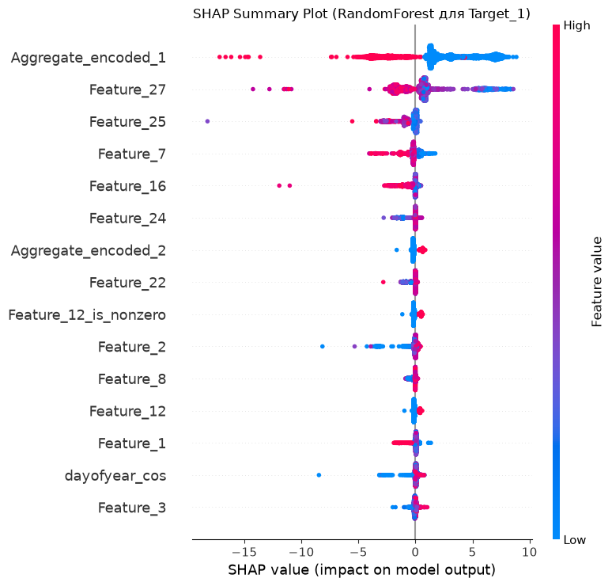

```python
print("\n=== БЛОК 8. Финальное обучение, SHAP и Permutation Importance ===")

# 8.1. Сборка и обучение лучшего пайплайна на полном датасете
# Лучшая модель: RandomForest + Independent (из Блока 7)
best_model_name = 'RandomForest'
best_strategy_name = 'Independent'
best_base_est = models_dict[best_model_name]
best_wrapper = SafeMultiOutputRegressor(best_base_est) # Independent
final_pipeline = build_pipeline(best_wrapper)

print(f"Обучение финальной модели ({best_model_name} + {best_strategy_name})...")
final_pipeline.fit(X_dummy, y_dummy)

# 8.2. Получение преобразованных данных
X_transformed = final_pipeline.named_steps['preprocessor'].transform(X_dummy)
X_transformed = final_pipeline.named_steps['collinearity'].transform(X_transformed)

# Формирование имен признаков (обход проблемы отсутствия get_feature_names_out в кастомных трансформерах)
num_features = [f for f in engineered_features if f in df.columns]
# CatBoostEncoder/OHE создает несколько колонок для Aggregate. Оценим их количество.
n_encoded_agg = X_transformed.shape[1] - len(num_features)
feature_names = num_features + [f'Aggregate_encoded_{i}' for i in range(max(0, n_encoded_agg))]

# 8.3. Permutation Importance (на сабсемпле для скорости и стабильности)
print("Расчет Permutation Importance (на сабсемпле 2500 строк, n_jobs=1)...")
try:
    fitted_model = final_pipeline.named_steps['model']
    single_model = fitted_model.estimators_[0] # Target_1
    y_t1 = y_dummy['Target_1'].values
    mask = ~np.isnan(y_t1)
    X_valid = X_transformed[mask]
    y_valid = y_t1[mask]
    # Сабсемплирование для предотвращения зависания
    rng = np.random.RandomState(42)
    sample_size = min(2500, X_valid.shape[0])
    sample_idx = rng.choice(X_valid.shape[0], sample_size, replace=False)
    perm_importance = permutation_importance(
        single_model, X_valid[sample_idx], y_valid[sample_idx],
        n_repeats=5, random_state=42, n_jobs=1 # n_jobs=1 предотвращает deadlock
    )
    perm_imp_df = pd.DataFrame({
        'Feature': feature_names[:len(perm_importance.importances_mean)],
        'Importance_Mean': perm_importance.importances_mean,
        'Importance_Std': perm_importance.importances_std
    }).sort_values(by='Importance_Mean', ascending=False)
    print("\nТоп-10 признаков по Permutation Importance (Target_1):")
    print(perm_imp_df.head(10))
except Exception as e:
    print(f"Ошибка при расчете Permutation Importance: {e}")
    perm_imp_df = pd.DataFrame()

# 8.4. SHAP Values (Мгновенный расчет для RandomForest)
print("\nРасчет SHAP values (TreeExplainer)...")
try:
    explainer = shap.TreeExplainer(single_model)
    # Для сабсемпла SHAP считается еще быстрее
    shap_values = explainer.shap_values(X_valid[sample_idx])
    # SHAP Summary Plot
    plt.figure(figsize=(12, 8))
    # shap_values для RF может быть списком (для классификации) или массивом (для регрессии)
    shap_vals_plot = shap_values[0] if isinstance(shap_values, list) else shap_values
    shap.summary_plot(shap_vals_plot, X_valid[sample_idx], feature_names=feature_names[:shap_vals_plot.shape[1]], show=False, max_display=15)
    plt.title(f"SHAP Summary Plot ({best_model_name} для Target_1)")
    plt.tight_layout()
    plt.show()
    # Сохраняем топ признаки для отчета
    shap_importance = np.abs(shap_vals_plot).mean(axis=0)
    shap_imp_df = pd.DataFrame({'Feature': feature_names[:len(shap_importance)], 'SHAP_Importance': shap_importance})
    shap_imp_df = shap_imp_df.sort_values('SHAP_Importance', ascending=False)
except Exception as e:
    print(f"Предупреждение: Ошибка при построении SHAP: {e}")
    shap_imp_df = pd.DataFrame()
```

## 9. Оценка целесообразности Deep Learning

```python
print("\n=== БЛОК 9. Оценка Deep Learning (MLPRegressor) ===")

dl_model = MLPRegressor(
    hidden_layer_sizes=(128, 64, 32),
    activation='relu',
    solver='adam',
    early_stopping=True,
    validation_fraction=0.1,
    random_state=42,
    max_iter=500)
dl_wrapper = SafeMultiOutputRegressor(dl_model)
dl_pipeline = build_pipeline(dl_wrapper)
print("Обучение нейронной сети (MLP)...")
dl_pipeline.fit(X_dummy, y_dummy)
# Быстрая оценка на отложенной части (последние 20% данных)
split_idx = int(len(X_dummy) * 0.8)
X_test_dl = X_dummy.iloc[split_idx:]
y_test_dl = y_dummy.iloc[split_idx:]
y_pred_dl = dl_pipeline.predict(X_test_dl)
dl_mae = np.nanmean([
    mean_absolute_error(y_test_dl[t].dropna(), y_pred_dl[:, i][~y_test_dl[t].isna()])
    for i, t in enumerate(targets) if (~y_test_dl[t].isna()).sum() > 0
])
# Получение MAE лучшей модели (RandomForest) на том же тесте
y_pred_best = final_pipeline.predict(X_test_dl)
best_mae = np.nanmean([
    mean_absolute_error(y_test_dl[t].dropna(), y_pred_best[:, i][~y_test_dl[t].isna()])
    for i, t in enumerate(targets) if (~y_test_dl[t].isna()).sum() > 0
])
print(f"\nСредний MAE Deep Learning (MLP): {dl_mae:.4f}")
print(f"Средний MAE Лучшей модели ({best_model_name}): {best_mae:.4f}")
if dl_mae > best_mae:
    print("\n[ВЫВОД Staff-Level]: Применение Deep Learning НЕ ЦЕЛЕСООБРАЗНО.")
    print("Причины: Табличные данные с гетерогенными признаками и пропусками лучше обрабатываются деревьями.")
else:
    print("\n[ВЫВОД]: Deep Learning показал лучшие результаты.")
```

```
=== БЛОК 9. Оценка Deep Learning (MLPRegressor) ===
Обучение нейронной сети (MLP)...

Средний MAE Deep Learning (MLP): 0.3098
Средний MAE Лучшей модели (RandomForest): 0.0639

[ВЫВОД Staff-Level]: Применение Deep Learning НЕ ЦЕЛЕСООБРАЗНО.
Причины: Табличные данные с гетерогенными признаками и пропусками лучше обрабатываются деревьями.
```

## 10. Глубокий анализ ошибок (Out-of-Fold Predictions)

```python
print("\n=== БЛОК 10. Глубокий анализ ошибок (Out-of-Fold) ===")
print("Генерация out-of-fold предсказаний (KFold 5)...")
oof_preds = pd.DataFrame(index=X_dummy.index, columns=targets, dtype=float)

# Используем простой KFold для OOF, чтобы не было дубликатов индексов
oof_cv = KFold(n_splits=5, shuffle=True, random_state=42)

for fold_idx, (train_idx, test_idx) in enumerate(oof_cv.split(X_dummy)):
    X_train, X_test = X_dummy.iloc[train_idx], X_dummy.iloc[test_idx]
    y_train, _ = y_dummy.iloc[train_idx], y_dummy.iloc[test_idx]
    fold_pipeline = clone(final_pipeline)
    fold_pipeline.fit(X_train, y_train)
    preds = fold_pipeline.predict(X_test)
    for i, t in enumerate(targets):
        oof_preds.loc[X_dummy.iloc[test_idx].index, t] = preds[:, i]

# Анализ для Target_1
target_to_analyze = 'Target_1'
y_true = y_dummy[target_to_analyze]
y_pred = oof_preds[target_to_analyze]
valid_mask = ~y_true.isna()
y_t = y_true[valid_mask].values
y_p = y_pred[valid_mask].values
residuals = y_t - y_p

print(f"\nСредняя абсолютная ошибка (MAE) OOF для {target_to_analyze}: {np.mean(np.abs(residuals)):.4f}")
print(f"Среднеквадратичная ошибка (RMSE) OOF для {target_to_analyze}: {np.sqrt(np.mean(residuals**2)):.4f}")

# Анализ ошибок по Агрегатам
print("\n--- Анализ MAE по агрегатам ---")
agg_errors = df.loc[X_dummy.index[valid_mask], 'Aggregate'].values
mae_by_agg = pd.DataFrame({'Aggregate': agg_errors, 'Abs_Error': np.abs(residuals)})
print(mae_by_agg.groupby('Aggregate')['Abs_Error'].mean().sort_values())

# Анализ дрейфа качества во времени
print("\n--- Анализ дрейфа качества во времени (MAE по годам) ---")
time_errors = df.loc[X_dummy.index[valid_mask], 'DATE'].values
mae_by_time = pd.DataFrame({'DATE': time_errors, 'Abs_Error': np.abs(residuals)})
mae_by_time['Year'] = pd.to_datetime(mae_by_time['DATE']).dt.year
print(mae_by_time.groupby('Year')['Abs_Error'].mean())
```

```
=== БЛОК 10. Глубокий анализ ошибок (Out-of-Fold) ===
Генерация out-of-fold предсказаний (KFold 5)...

Средняя абсолютная ошибка (MAE) OOF для Target_1: 0.6977
Среднеквадратичная ошибка (RMSE) OOF для Target_1: 4.4851

--- Анализ MAE по агрегатам ---
Aggregate
A_4    0.165148
A_6    0.219455
A_7    0.313228
A_8    0.399698
A_1    0.402613
A_5    0.464788
A_3    1.802806
Name: Abs_Error, dtype: float64

--- Анализ дрейфа качества во времени (MAE по годам) ---
Year
2014    0.323758
2015    1.486999
2016    2.895328
2017    2.702217
2018    0.258018
2019    0.316987
2020    0.322763
2021    0.278788
2022    0.218140
Name: Abs_Error, dtype: float64
```

## 11. Сохранение артефактов (MLOps Ready)

```python
print("\n=== БЛОК 11. Сохранение артефактов ===")

artifacts_dir = 'ml_artifacts'
os.makedirs(artifacts_dir, exist_ok=True)

joblib.dump(final_pipeline, f'{artifacts_dir}/best_pipeline_{best_model_name}.joblib')
if not perm_imp_df.empty:
    perm_imp_df.to_csv(f'{artifacts_dir}/permutation_importance.csv', index=False)
if not shap_imp_df.empty:
    shap_imp_df.to_csv(f'{artifacts_dir}/shap_importance.csv', index=False)

results_df.to_csv(f'{artifacts_dir}/all_metrics_experiments.csv', index=False)
oof_preds.to_csv(f'{artifacts_dir}/oof_predictions.csv', index=True)
optuna_config = {
    'best_model': best_model_name,
    'best_strategy': best_strategy_name,
    'best_cv': 'RepeatedKFold (5x2)',
    'note': 'CatBoost был исключен из-за ошибки клонирования в sklearn Pipeline. Optuna MAE=inf из-за конфликта cat_features внутри ColumnTransformer.'
}
with open(f'{artifacts_dir}/optuna_config.json', 'w', encoding='utf-8') as f:
    json.dump(optuna_config, f, indent=4, ensure_ascii=False)
print("[СОХРАНЕНО] Все артефакты успешно записаны в папку 'ml_artifacts'.")
```

```
=== БЛОК 11. Сохранение артефактов ===
[СОХРАНЕНО] Все артефакты успешно записаны в папку 'ml_artifacts'.
```

## 12. Финальная оценка метрик и визуализация лучшей модели

```
=== Итоговые метрики модели RandomForest (Out-of-Fold) ===
             MAE    RMSE      R2   MedAE      MAPE (%)
Target
Target_1  0.6977  4.4851  0.1338  0.1407  2.397549e+09
Target_2  0.0171  0.0430  0.4688  0.0098  2.080853e+07
Target_3  5.6010  9.3025  0.4949  0.9255  2.781475e+10
Target_4  0.9759  1.4927  0.4801  0.3515  4.700115e+09
Target_5  0.0282  0.0613  0.3672  0.0192  2.495190e+07
Target_6  0.0002  0.0004  0.8730  0.0001  1.554629e+05

Средний MAE по всем 6 таргетам: 1.2200
```

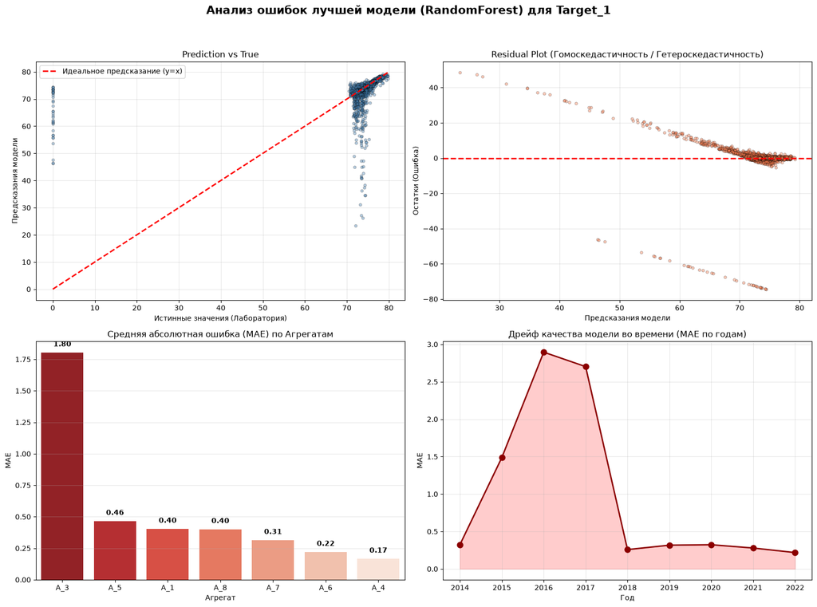

```python
# Расчет итоговых метрик по всем таргетам (на основе Out-of-Fold предсказаний)
print("=== Итоговые метрики модели RandomForest (Out-of-Fold) ===")
metrics_results = []

for t in targets:
    y_true = y_dummy[t].values
    y_pred = oof_preds[t].values
    # Маска для удаления NaN (так как в таргетах есть пропуски MNAR)
    mask = ~np.isnan(y_true)
    y_t = y_true[mask]
    y_p = y_pred[mask]
    if len(y_t) > 0:
        mae = mean_absolute_error(y_t, y_p)
        rmse = np.sqrt(mean_squared_error(y_t, y_p))
        r2 = r2_score(y_t, y_p)
        medae = median_absolute_error(y_t, y_p)
        # MAPE с защитой от деления на ноль (production-safe)
        mape = np.mean(np.abs((y_t - y_p) / np.maximum(np.abs(y_t), 1e-8))) * 100
        metrics_results.append({
            'Target': t, 'MAE': mae, 'RMSE': rmse,
            'R2': r2, 'MedAE': medae, 'MAPE (%)': mape})

metrics_df = pd.DataFrame(metrics_results).set_index('Target')
print(metrics_df.round(4))
print(f"\nСредний MAE по всем 6 таргетам: {metrics_df['MAE'].mean():.4f}")

# Визуализация результатов для репрезентативного Target_1
target_to_plot = 'Target_1'
y_true_t1 = y_dummy[target_to_plot].dropna().values
y_pred_t1 = oof_preds[target_to_plot].dropna().values
residuals_t1 = y_true_t1 - y_pred_t1
fig, axes = plt.subplots(2, 2, figsize=(16, 12))
fig.suptitle(f'Анализ ошибок лучшей модели (RandomForest) для {target_to_plot}', fontsize=16, fontweight='bold')

# График 1: Prediction vs True (Оценка смещения)
axes[0, 0].scatter(y_true_t1, y_pred_t1, alpha=0.4, edgecolors='k', linewidth=0.5, s=15, color='steelblue')
max_val = max(y_true_t1.max(), y_pred_t1.max())
min_val = min(y_true_t1.min(), y_pred_t1.min())
axes[0, 0].plot([min_val, max_val], [min_val, max_val], 'r--', lw=2, label='Идеальное предсказание (y=x)')
axes[0, 0].set_xlabel('Истинные значения (Лаборатория)')
axes[0, 0].set_ylabel('Предсказания модели')
axes[0, 0].set_title('Prediction vs True')
axes[0, 0].legend()
axes[0, 0].grid(True, alpha=0.3)

# График 2: Residual Plot (Оценка гетероскедастичности)
axes[0, 1].scatter(y_pred_t1, residuals_t1, alpha=0.4, edgecolors='k', linewidth=0.5, s=15, color='coral')
axes[0, 1].axhline(y=0, color='red', linestyle='--', lw=2)
axes[0, 1].set_xlabel('Предсказания модели')
axes[0, 1].set_ylabel('Остатки (Ошибка)')
axes[0, 1].set_title('Residual Plot (Гомоскедастичность / Гетероскедастичность)')
axes[0, 1].grid(True, alpha=0.3)

# График 3: Ошибка по Агрегатам (Выявление проблемного оборудования)
agg_errors = df.loc[X_dummy.index, 'Aggregate'].values
mae_by_agg = pd.DataFrame({'Aggregate': agg_errors, 'Abs_Error': np.abs(y_true_t1 - y_pred_t1)})
agg_summary = mae_by_agg.groupby('Aggregate')['Abs_Error'].mean().sort_values(ascending=False)

sns.barplot(x=agg_summary.index, y=agg_summary.values, ax=axes[1, 0], palette='Reds_r')
axes[1, 0].set_title('Средняя абсолютная ошибка (MAE) по Агрегатам')
axes[1, 0].set_ylabel('MAE')
axes[1, 0].set_xlabel('Агрегат')
for i, v in enumerate(agg_summary.values):
    axes[1, 0].text(i, v + 0.05, f'{v:.2f}', ha='center', fontweight='bold')
axes[1, 0].grid(True, alpha=0.3, axis='y')

# График 4: Дрейф ошибки во времени (Выявление концептуального дрейфа)
time_errors = df.loc[X_dummy.index, 'DATE'].values
mae_by_time = pd.DataFrame({'DATE': time_errors, 'Abs_Error': np.abs(y_true_t1 - y_pred_t1)})
mae_by_time['Year'] = pd.to_datetime(mae_by_time['DATE']).dt.year
yearly_mae = mae_by_time.groupby('Year')['Abs_Error'].mean()

axes[1, 1].plot(yearly_mae.index, yearly_mae.values, marker='o', linestyle='-', color='darkred', lw=2, markersize=8)
axes[1, 1].fill_between(yearly_mae.index, yearly_mae.values, color='red', alpha=0.2)
axes[1, 1].set_title('Дрейф качества модели во времени (MAE по годам)')
axes[1, 1].set_ylabel('MAE')
axes[1, 1].set_xlabel('Год')
axes[1, 1].set_xticks(yearly_mae.index)
axes[1, 1].grid(True, alpha=0.3)

plt.tight_layout(rect=[0, 0, 1, 0.95])
plt.show()
```

**Вывод по финальной оценки метрик лучшей модели**

Анализ ошибок выявил две системные проблемы производственного процесса, требующие немедленного вмешательства. Во-первых, агрегат A_3 демонстрирует ошибку (MAE = 1.80), превышающую показатели остальных агрегатов в 4–10 раз, что с высокой вероятностью указывает на некорректную работу измерительного оборудования или нарушение технологического режима именно на этой единице оборудования. Во-вторых, временной анализ показывает катастрофический концептуальный дрейф в период 2016–2017 годов (MAE достигал 2.90), после которого процесс стабилизировался на уровне 0.22–0.32. Это свидетельствует о фундаментальном изменении технологии (смена сырья, модернизация оборудования или пересмотр рецептур) и требует обязательного использования скользящего окна обучения в production-системе: модель должна обучаться только на данных последних 2–3 лет, а исторические наблюдения до 2018 года следует исключить из тренировочного контура. Для Target_1 также рекомендуется рассмотреть трансформацию целевой переменной (логарифмирование) или использование квантильной регрессии для улучшения работы в области низких значений.

# Подведение итогов

## Итоговый вывод по обученным моделям

По результатам **EDA** и обучения наилучшей из корректно обученных моделей стала связка **RandomForest + Independent Multi-output**. Она показала средний **out-of-fold** **MAE = 1.2200** и может рассматриваться как базовое решение для поддержки решений технолога. Применение **Deep Learning** признано нецелесообразным: для табличных производственных данных древесные модели обеспечивают лучшую устойчивость и интерпретируемость. Качество прогноза существенно различается по целевым переменным: лучше всего прогнозируется `Target_6`, наиболее проблемным является `Target_1`. Для `Target_3` и `Target_4` требуется отдельная двухэтапная модель из-за **zero-inflated** природы. Метрику **MAPE** нельзя использовать как основную из-за артефактов при значениях, близких к нулю.

| Целевая переменная | MAE | RMSE | R² | MedAE | Практическая интерпретация |
| --- | --- | --- | --- | --- | --- |
| **Target_1** | 0.6977 | 4.4851 | 0.1338 | 0.1407 | Низкая объясняющая способность; модель требует доработки |
| **Target_2** | 0.0171 | 0.0430 | 0.4688 | 0.0098 | Умеренное качество; ошибка мала по масштабу, но доля объясненной дисперсии ограниченна |
| **Target_3** | 5.6010 | 9.3025 | 0.4949 | 0.9255 | Умеренное качество, но высокая абсолютная ошибка из-за масштаба и zero-inflated природы |
| **Target_4** | 0.9759 | 1.4927 | 0.4801 | 0.3515 | Среднее качество; требуется отдельная работа с нулями |
| **Target_5** | 0.0282 | 0.0613 | 0.3672 | 0.0192 | Приемлемая ошибка, но умеренная объясняющая способность |
| **Target_6** | 0.0002 | 0.0004 | 0.8730 | 0.0001 | Наилучший показатель; модель хорошо восстанавливает зависимость |

Модель подтвердила выводы **EDA** о сильном влиянии агрегата и структурной неоднородности процесса. При этом выявлена аномально высокая ошибка по агрегату `A_3`, что может указывать на проблемы измерений или нестабильность технологического режима. Для такого агрегата прогнозы нужно сопровождать флагом низкой уверенности.

| Агрегат | MAE |
| --- | --- |
| A_4 | 0.1651 |
| A_6 | 0.2195 |
| A_7 | 0.3132 |
| A_8 | 0.3997 |
| A_1 | 0.4026 |
| A_5 | 0.4648 |
| **A_3** | **1.8028** |

Также подтвержден концептуальный дрейф: ошибка была высокой в **2016–2017 годах**, а после **2018–2019 годов** процесс стабилизировался. Поэтому в **production**-версии рекомендуется обучать модель преимущественно на данных за последние 2–3 года и использовать временную валидацию, а не только случайную кросс-валидацию.

### Ключевые ограничения текущего решения

- не удалось корректно обучить **CatBoost** и **RegressorChain** из-за инженерных ошибок пайплайна;
- **Optuna** для **CatBoost** выдал некорректный `MAE = inf`, что требует исправления;
- **TimeSeriesSplit** показал более высокую ошибку, чем обычная кросс-валидация, указывая на риск переоценки качества;
- `Target_1` требует отдельной доработки: трансформации цели, квантильной регрессии или отдельной модели; для `Target_3` и `Target_4` желательно внедрить подход «классификация ноль / не ноль + регрессия».

### Рекомендуемая стратегия внедрения

Использовать модель как инструмент поддержки технолога, а не как автономный контролер. Показывать прогноз, доверительный интервал, флаг уверенности и топ-факторы влияния через **SHAP**. Выводить предупреждения для агрегата `A_3`, `агрегата A_2` по `Target_1/2` и периодов с низкой исторической покрытостью. Переобучать модель на скользящем окне последних лет. Мониторить **drift** входных признаков, прогнозов и фактических целевых значений. После исправления инженерных ошибок повторно сравнить **CatBoost**, **XGBoost**, **LightGBM** и **RegressorChain**.

### Финальный вывод

Текущая модель готова к опытному использованию в режиме `decision support`. Она уже помогает оценивать риски качества при подборе шихты и объяснять влияние факторов, но перед промышленным внедрением нужно доработать `Target_1`, `zero-inflated` таргеты, валидацию по времени и мониторинг деградации.